# In-class_Ex04

Hands-on Exercise

Author

Shermainn

Published

October 5, 2025

Modified

May 10, 2025

# Recap:

- Take home exercise 2: Do mini challenge 1 - analyze on the various questions shown, do not need to do the reflection questions
- Take home exercise 3: To do a prototype: deadline - 15th June (try to do it asap before week 8 so that can proceed to the project), come up with a storyboard and necessary R packages in the Shiny environment, don’t need to build up the whole application

# Lesson 4

- Two sample mean - EDA, need to do sampling test regardless of sample size (n >30 still need to do!)
- Use this website to have best practices and reference for ggstatsplot [here](https://indrajeetpatil.github.io/ggstatsplot/articles/web_only/ggbetweenstats.html).

  One-way Anova:
- To compare between different plots use `pairwise.comparisons`
- for `pairwise.display` there are 3 types to use as shown below.
1. “ns” → only non-significant
2. “s” → only significant
3. “all” → everything
- ggridges - refer to [here](https://wilkelab.org/ggridges/).
- To use `facet_wrap()` if you want to compare based on each baseline as shown in the image below. Note: will be displayed into different charts.

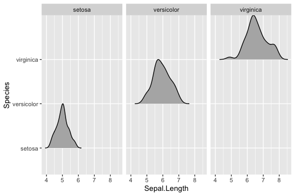

Facet-wrap by species each density curve by baseline

- Half-Eye Plot: Violin Plot is divided in half, and then used boxplot to show the median, max and min points as well as dot plot to show the number of data points
- HOPS:

  When moves slower, means more certain about the data sets and bigger sample size with smaller variability.

  When moves faster, means less certain about the data sets and smaller sample size and bigger variability,